# Gestion de données tabulaires

## Expression du besoin

De nombreuses applications manipulent des données sous forme de tableau et il est souvent nécessaire des les stocker dans des fichiers. Ces fichiers peuvent être créés ou exploités par des outils externes comme les logiciels de type **tableur** (Microsoft Excel, LibreOffice/OpenOffice calc, …). Le format CSV répond à ces besoins en étant un format d’échange non propriétaire et extrêmement simple à gérer.

## Fichier CSV

Le format CSV (*Comma-separated values*) est un **format informatique ouvert** représentant des **données tabulaires** sous forme de valeurs séparées par un **délimiteur** (initialement des virgules).

*Remarque :* Le format CSV n’a jamais vraiment fait l’objet d’une spécification formelle. Toutefois, la RFC 4180 décrit la forme la plus courante et établit son type **MIME** « `text/csv` », enregistré auprès de l’IANA.

Les séparateurs ne sont pas standardisés (virgules, points-virgules, etc…) rend ce format peu pratique pour une utilisation autre que des échanges de données ponctuels. Ce format est toutefois très populaire parce qu’il est très facile à générer.

*Remarque :* de plus en plus de logiciels utilisent le format **XML** (*Extensible Markup Language*) pour l’échange de données (voir l’activité sur les fichiers XML).

Les fichiers CSV sont des **fichiers texte** : ils peuvent donc être manipulés avec un éditeur de texte. Mais les fichiers CSV sont essentiellement utilisés par des logiciels de type **tableur** (Microsoft Excel, LibreOffice/OpenOffice calc, …).

Chaque ligne du texte correspond à une **ligne du tableau** et les virgules correspondent aux **séparations entre les colonnes**. Les portions de texte séparées par une virgule correspondent ainsi aux **contenus des cellules** du tableau.

Une ligne est une suite ordonnée de caractères terminée par un caractère de fin de ligne (CRLF), la dernière ligne pouvant en être exemptée.

Exemple de fichier CSV :

```
Sexe,Prénom,Année de naissance
M,Alphonse,1932
F,Béatrice,1964
F,Charlotte,1988
```

Lorsque l’on ouvre ce type de fichier avec un tableur, celui peut demander à choisir le séparateur à utiliser :

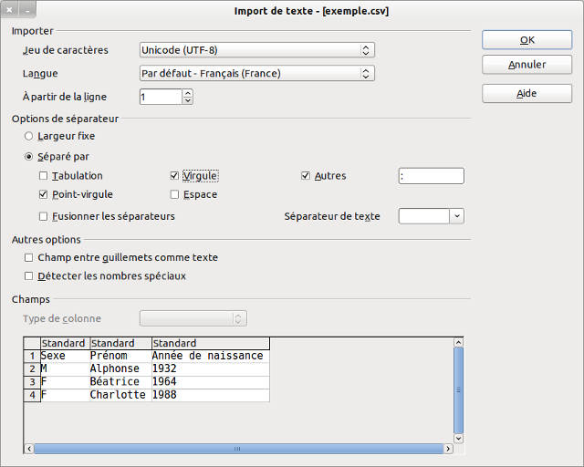

La feuille de calcul que l’on obtient ici :

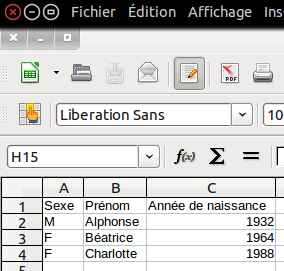

*Remarque :* Les champs texte peuvent également être délimités par des guillemets. Lorsqu’un champ contient lui-même des guillemets, ils sont doublés afin de ne pas être considérés comme début ou fin du champ. Si un champ contient un signe utilisé comme séparateur de colonne (virgule, point-virgule, tabulation, etc.) ou comme séparateur de ligne (généralement le caractère de retour à la ligne), les guillemets sont obligatoires afin que ce signe ne soit pas confondu avec un séparateur.

## API Qt

Qt ne fournit pas de classe capable de gérer directement des fichiers CSV. On utilisera donc la classe `QFile` qui permet de manipuler des fichiers.

- [La classe QFile Qt4 (en)](http://doc.qt.io/qt-4.8/qfile.html)
- [La classe QFile Qt5 (en)](http://doc.qt.io/qt-5/qfile.html)
- [FAQ QFile (fr)](http://qt.developpez.com/faq/?page=modules-qtcore-fichiers-lectureecriture)

# Objectifs

Être capable de lire et écrire dans un fichier CSV des données tabulaires.

## Séquence 1 : écrire un fichier CSV

On va créer une application GUI qui simule une acquisition de mesures de température et qui les affiche dans un tableau. L’application devra être capable d’enregistrer dans un fichier `datas.csv` ces mesures horodatées au format CSV.

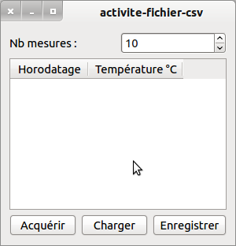

Il est possible de choisir le nombre de mesures à réaliser puis, on lance l’acquisition en cliquant sur le bouton Acquérir :

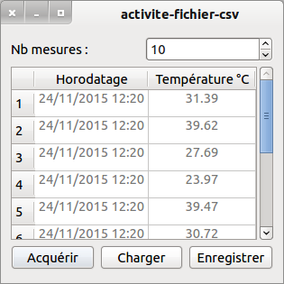

On utilisera le séparateur ‘`;`’ et on protégera les données avec des guillemets ‘`"`’ :

```
Horodatage;Température °C
"24/11/2015 12:23";"25,12"
"24/11/2015 12:24";"31,37"
"24/11/2015 12:25";"38,63"
"24/11/2015 12:26";"37,34"
"24/11/2015 12:27";"33,93"
"24/11/2015 12:28";"20,19"
"24/11/2015 12:29";"34,28"
"24/11/2015 12:30";"29,42"
"24/11/2015 12:31";"25,99"
"24/11/2015 12:32";"31,82"
```

Pour manipuler ces mesures dans le programme, on définira cette structure de données :

```cpp
typedef struct
{
    QString horodatage; // de la forme "dd/MM/yyyy hh:mm"
    double  valeur; // ici une température en °C
} Mesure;
```

L’objectif est d’écrire dans un fichier CSV lorsqu’on clique sur le bouton Enregistrer.

On vous fournit la méthode `ecrireCSV()` qu’il vous faudra tester :

```cpp
bool MaFenetre::ecrireCSV()
{
    // Le fichier CSV
    QFile *fichierCSV = new QFile("datas.csv");

    // Ouverture du fichier en mode texte et en écriture seule
    if (fichierCSV->open(QFile::WriteOnly | QIODevice::Text))
    {
        // Ecriture de l'en-tête
        QTextStream entete(fichierCSV);
        entete << QString::fromUtf8("Horodatage;Température °C") << endl;
    }
    else
    {
        QMessageBox::critical(0,"Erreur !",("Impossible d'ouvrir le fichier datas.csv"));
        delete fichierCSV;

        return false;
    }

    // Ecriture des données
    QTextStream datas(fichierCSV);
    QString data;

    // on récupère toutes les mesures et on les écrit dans le fichier
    int n = 0;
    while ( n < mesures.size() )
    {
        data = mesures[n].horodatage;
        datas << "\"" << data << "\""; // on protège la data avec des "
        datas << ";";
        data = QString::number(mesures[n].valeur);
        //data.sprintf("%.2f", mesures[n].valeur);
        // A la française ?
        data.replace(QString("."), QString(","));
        datas << "\"" << data << "\""; // on protège la data avec des "
        datas << endl;
        ++n;
    }

    // On ferme le fichier
    fichierCSV->close();

    delete fichierCSV;

    return true;
}
```

**Code source fourni :** activite-fichier-csv.zip

1. Tester l’application fournie.

## Séquence 2 : lire dans un fichier CSV

2. Implémenter le chargement et l’affichage de mesures en provenance d’un fichier CSV.
1. écrire le *slot* `charger()` qui doit permettre d’ouvrir le fichier CSV de son choix (cf. `QFileDialog::getOpenFileName()`) :

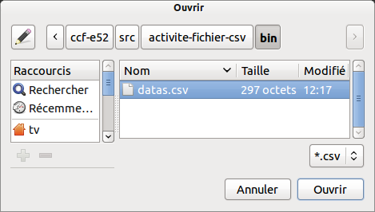

2. écrire la méthode `lireCSV()` et tester l’affichage des données lues

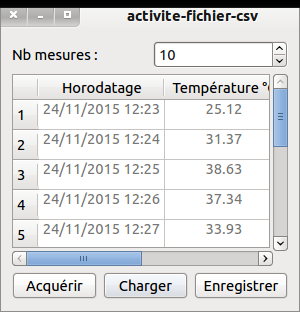

Retour au sommaire